# BANA 4080: Introduction to Data Mining with Python

Week 9: Correlation & Regression Foundations

## Welcome to Week 9

- Quick overview of today’s plan:
  - Understanding relationships between business variables
  - Guess the Correlation team challenge
  - From correlation to prediction with linear regression
  - Evaluating model performance for business decisions

## 📓 Follow Along in the Notebook

**Week 9 Lecture Notebook**

Open the companion notebook in Colab now and follow along as we work through today’s examples on correlation, regression, and model evaluation.

[figure not shown]

Open In Colab

# Week 8 Recap

## Last Week in 60 Seconds

🎯 Supervised learning

We have a **target** to learn from (an “answer key”)

**Regression** — predict a *number*

*How much will this customer spend next month?*

**Classification** — predict a *category*

*Will this customer cancel?*

🔍 Unsupervised learning

**No target**: the algorithm finds structure on its own

**Clustering** — discover *groups*

*What types of shoppers do we have?*

**Tip**

This week we go deep on the first one: **regression**.

## Spot the Model

**What’s one regression or classification model you interacted with this past week?**

What was it predicting? Was the output a number or a category?

**A couple of mine:**

- ⛳ **Arccos golf app** *(regression)*: predicts a “plays like” distance from the actual distance, wind, humidity, temperature, and slope
- 🏈 **Yahoo Fantasy Football** *(classification)*: predicts who will win this week’s matchup

# Understanding Relationships in Business

## Why Relationships Matter

In business, we rarely care about a single number in isolation. Leaders ask questions like:

- *Does increasing marketing spend actually increase sales?*
- *Are higher salaries associated with better employee retention?*
- *Do customers in certain regions spend more per transaction?*
- *Which factors drive customer satisfaction scores?*

**Today’s Goal:** Learn to measure and model these relationships quantitatively.

## Think-Pair-Share: Business Relationships

Think about your work experience, internships, or daily life:

- **What’s one relationship between two things that you’ve noticed?**
  - Example: “Study time and exam grades seem connected”
- **How strong do you think that relationship is?**
- **Could you use one to predict the other?**

Share your examples with your partner!

Then we’ll take a few responses…

## What is Correlation?

**Correlation** measures how strongly two variables move together in a linear relationship.

- **Range**: -1 to +1
- **+1**: Perfect positive relationship
- **0**: No linear relationship
- **-1**: Perfect negative relationship

**Key Insight:** Correlation is descriptive, it tells you variables move together, but **not why**.

**Your turn**

Give me a business or everyday example of a **positive**, a **negative**, and **no** correlation.

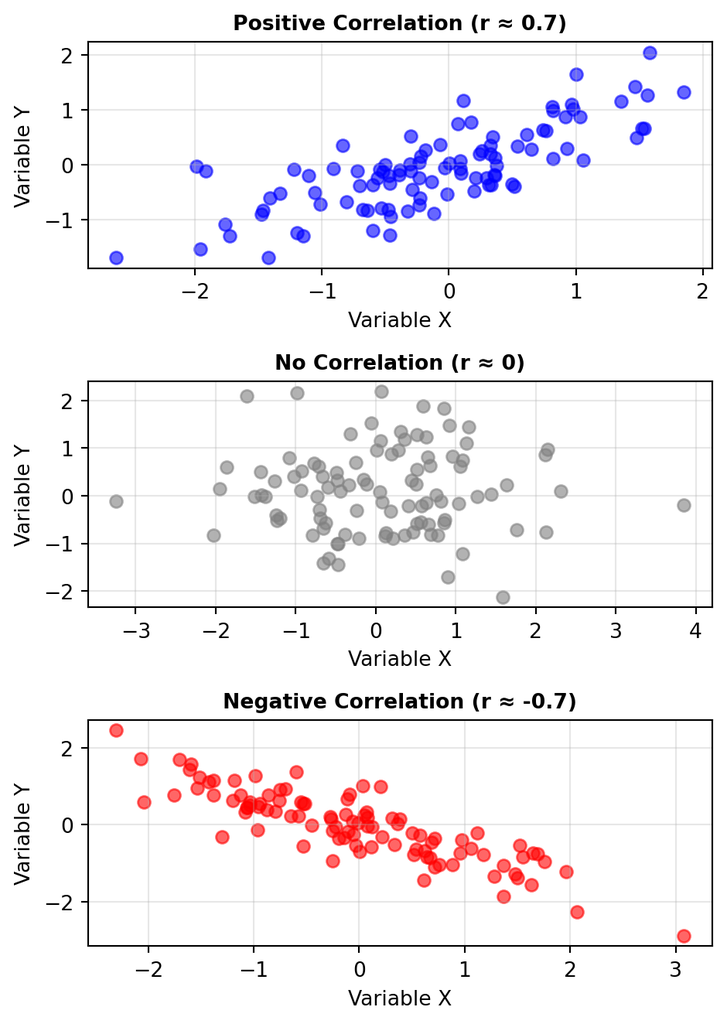

# Team Challenge: Guess the Correlation!

## Team Challenge: Guess the Correlation!

**Setup & Game Link**

**Teams:** I’m dividing the room into 2-3 teams

**Game:** We’ll use the interactive game at [guessthecorrelation.com](https://www.guessthecorrelation.com/)

**How it works:**

- Teams view scatterplots and guess correlation coefficients (-1 to +1)
- Track your team’s accuracy across multiple rounds
- See how close your intuition gets to the actual values!

**Scoring:** Keep track of your team’s average accuracy

**Prize:** Winning team gets extra credit bragging rights! 🎉

**Let’s play 5-10 rounds!**

## Challenge Results & Key Insights

**Congratulations to our winning team!** 🏆

**Key Takeaways from the Challenge:**

- **Visual patterns** help us estimate correlation strength
- **Intuition isn’t enough**: sometimes it matches the data, sometimes it doesn’t. Statistics help us test and refine our intuition
- **Perfect correlations** (±1.0) are rare in real business data
- **Direction matters**: Positive vs negative relationships tell different stories

**Next:** How do we move from measuring relationships to making predictions?

## Let’s Practice: Grocery Chain Data

**Your turn!** Let’s analyze some real grocery chain data.

**Show code for creating grocery chain dataset**

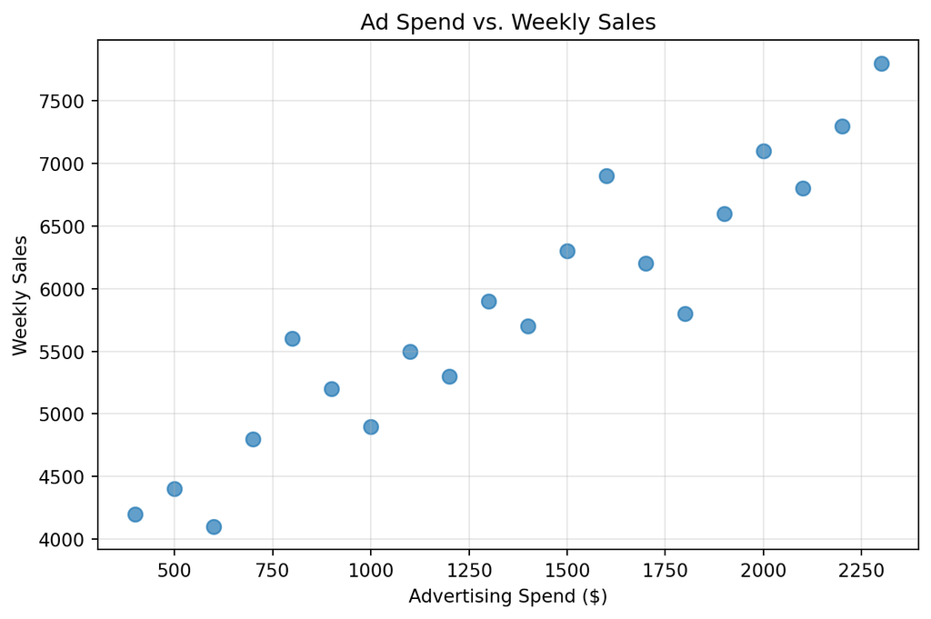

```python
import pandas as pd
import matplotlib.pyplot as plt
import numpy as np

# Example dataset: advertising spend vs. weekly sales
data = pd.DataFrame({
    "ad_spend": [400, 500, 600, 700, 800, 900, 1000, 1100, 1200, 1300, 1400, 1500, 1600, 1700, 1800, 1900, 2000, 2100, 2200, 2300],
    "weekly_sales": [4200, 4400, 4100, 4800, 5600, 5200, 4900, 5500, 5300, 5900, 5700, 6300, 6900, 6200, 5800, 6600, 7100, 6800, 7300, 7800]
})

# Visualize the relationship
plt.figure(figsize=(8, 5))
plt.scatter(data["ad_spend"], data["weekly_sales"], alpha=0.7, s=60)
plt.xlabel("Advertising Spend ($)")
plt.ylabel("Weekly Sales")
plt.title("Ad Spend vs. Weekly Sales")
plt.grid(True, alpha=0.3)
plt.show()
```

**Question for you:** What do you think the correlation is? Write down your guess!

## Computing Correlation

Let’s see how close your guess was!

```python
# Compute the correlation coefficient
correlation = data["ad_spend"].corr(data["weekly_sales"])
print(f"Correlation coefficient: {correlation:.3f}")

# Or we can see the full correlation matrix
print("\nFull correlation matrix:")
data.corr()
```

```
Correlation coefficient: 0.941

Full correlation matrix:
```

|  | ad_spend | weekly_sales |
| --- | --- | --- |
| ad_spend | 1.000000 | 0.941372 |
| weekly_sales | 0.941372 | 1.000000 |

**Interpretation:**

- Strong positive correlation (~0.9)
- As advertising spend increases, sales tend to increase
- **Remember:** Correlation ≠ causation!

# From Correlation to Regression

## From Correlation to Prediction

**We found a strong correlation (~0.9) between advertising and sales.**

**But now the business question is:** Can we use advertising spend to *predict* future sales?

**Question:** If you could draw a line to represent this relationship, what would it look like?

**Show code for plot**

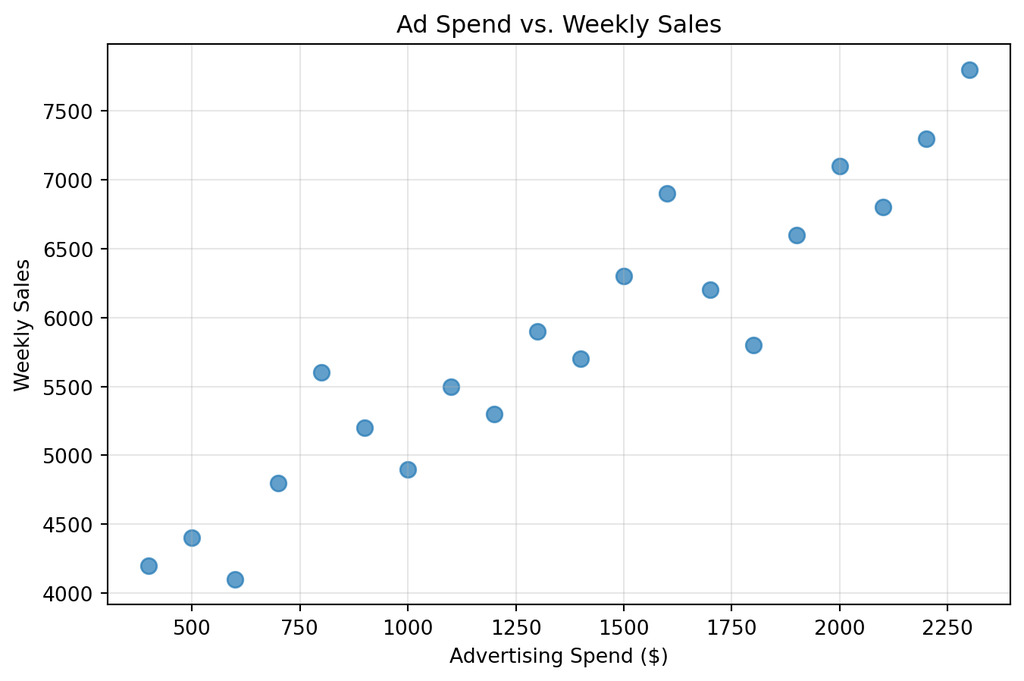

```python
import pandas as pd
import matplotlib.pyplot as plt
import numpy as np

# Visualize the relationship
plt.figure(figsize=(8, 5))
plt.scatter(data["ad_spend"], data["weekly_sales"], alpha=0.7, s=60)
plt.xlabel("Advertising Spend ($)")
plt.ylabel("Weekly Sales")
plt.title("Ad Spend vs. Weekly Sales")
plt.grid(True, alpha=0.3)
plt.show()
```

## The Linear Regression Formula

**Remember from high school?** The equation of a line:

$$y = mx + b$$

With linear regression, we follow a similar approach but the typical equation you’ll see is:

$$y = \beta_0 + \beta_1 x$$

Where:

- **y** = dependent variable (what we’re predicting)
- **x** = independent variable (what we’re using to predict)
- **β₁** = slope coefficient (how much y changes for each unit increase in x)
- **β₀** = intercept (value of y when x = 0)

**Important**

**The goal:** Find the best values for slope and intercept that minimize prediction errors!

## Fitting Our Regression Model

```python
from sklearn.linear_model import LinearRegression

# Prepare the data
X = data[["ad_spend"]]  # Feature matrix (note the double brackets)
y = data["weekly_sales"]  # Target variable

# Fit the model
model = LinearRegression()
model.fit(X, y)

# Extract the results
intercept = model.intercept_
slope = model.coef_[0]

print(f"Intercept (β₀): ${intercept:.0f}")
print(f"Slope (β₁): ${slope:.2f}")
```

```
Intercept (β₀): $3552
Slope (β₁): $1.68
```

**Our fitted equation:**
$$\text{Weekly Sales} = 3552 + 1.68 \times \text{Ad Spend}$$

**Interpretation:** For every $1 increase in advertising, we expect weekly sales to increase by $1.68!

## Visualizing Our Predictions

**Show code for regression line visualization**

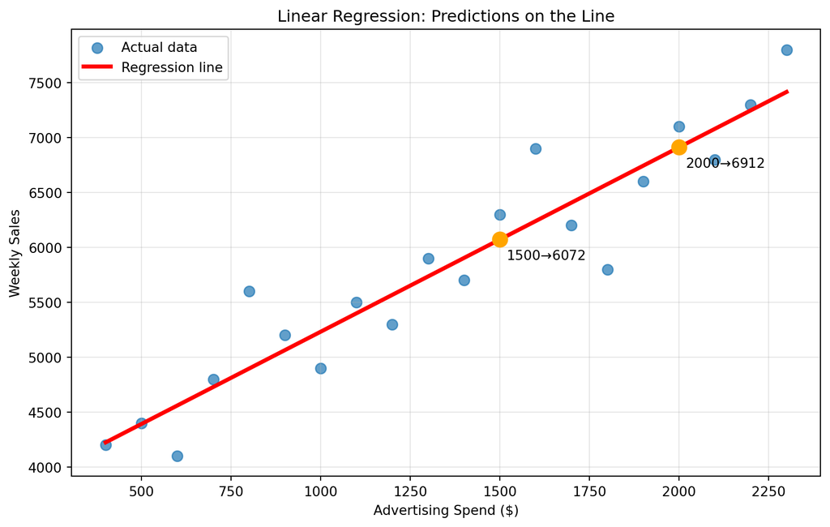

```python
# Create the regression line visualization
plt.figure(figsize=(10, 6))
plt.scatter(data["ad_spend"], data["weekly_sales"], alpha=0.7, s=60, label="Actual data")

# Add the fitted regression line
plt.plot(data["ad_spend"], model.predict(X), color="red", linewidth=3, label="Regression line")

# Show specific predictions
pred_x = [1500, 2000]
for x_val in pred_x:
    pred_y = model.predict([[x_val]])[0]
    plt.scatter(x_val, pred_y, color="orange", s=120, zorder=5)
    plt.annotate(f"${x_val} → ${pred_y:.0f}",
                xy=(x_val, pred_y), xytext=(5, -15),
                textcoords='offset points', fontsize=10)

plt.xlabel("Advertising Spend ($)")
plt.ylabel("Weekly Sales")
plt.title("Linear Regression: Predictions on the Line")
plt.legend()
plt.grid(True, alpha=0.3)
plt.show()
```

**Key insight:** Every prediction falls exactly on our regression line!

## Making Business Predictions

**Business value:** Now we can forecast sales for any advertising budget!

```python
# Make predictions for different scenarios
scenarios = pd.DataFrame({
    'ad_spend': [1500, 2500, 3000]
})

predictions = model.predict(scenarios)

print("Business Predictions:")
for spend, pred in zip(scenarios['ad_spend'], predictions):
    print(f"Spend ${spend:,} → Predicted Sales: ${pred:,.0f}")

# Manual calculation to verify
print(f"\nManual check for $1,500:")
manual_pred = 1.68 * 1500 + 3552
print(f"1.68 × 1500 + 3552 = ${manual_pred:.0f}")
```

```
Business Predictions:
Spend $1,500 → Predicted Sales: $6,072
Spend $2,500 → Predicted Sales: $7,752
Spend $3,000 → Predicted Sales: $8,592

Manual check for $1,500:
1.68 × 1500 + 3552 = $6072
```

## Critical Question

**We now have a model that can make predictions…**

- Advertising spend of $1,500 → $6,072 in sales
- Advertising spend of $2,500 → $7,752 in sales
- Advertising spend of $3,000 → $8,592 in sales

**Question 🤔**

How do we know if this is a GOOD model?

How would you assess prediction quality?

# Evaluating Model Performance

## Which Forecaster Would You Hire?

Two analysts forecast weekly sales for your store. Here’s their track record:

| Week | Actual Sales | Forecaster A | Forecaster B |
| --- | --- | --- | --- |
| 1 | $6,100 | $5,900 | $6,100 |
| 2 | $5,400 | $5,700 | $5,350 |
| 3 | $6,800 | $6,600 | $6,850 |
| 4 | $5,900 | $6,100 | $5,900 |
| 5 | $7,200 | $6,900 | $8,300 |

**With your neighbor:**

- Which forecaster would you hire?
- *How* did you decide?

## That’s Model Evaluation

To decide, you compared **predictions** with what **actually happened**, then summarized the misses. That’s all model evaluation is.

🔮 Predict

Have the model make predictions

➜

⚖️ Compare

Line them up with the actual outcomes

➜

📏 Summarize

Condense the misses into a single **metric**

➜

✅ Decide

Deploy it, improve it, or pick a better model

**Why bother?**

- **Trust**: would you bet next month’s inventory budget on a model you never checked?
- **Comparison**: a metric lets us pick the better of two models objectively
- **Communication**: “typically off by about $350” is something a manager can plan around

## RMSE: How Far Off, Typically?

**Root Mean Squared Error** turns a list of misses into one number: **①** find each error (actual − forecast), **②** square it, **③** take the mean, **④** take the square root.

|  |  | Forecaster A |  |  | Forecaster B |  |  |
| --- | --- | --- | --- | --- | --- | --- | --- |
| **Week** | **Actual** | **Forecast** | **① Error** | **② Error²** | **Forecast** | **① Error** | **② Error²** |
| 1 | $6,100 | $5,900 | +200 | 40,000 | $6,100 | 0 | 0 |
| 2 | $5,400 | $5,700 | −300 | 90,000 | $5,350 | +50 | 2,500 |
| 3 | $6,800 | $6,600 | +200 | 40,000 | $6,850 | −50 | 2,500 |
| 4 | $5,900 | $6,100 | −200 | 40,000 | $5,900 | 0 | 0 |
| 5 | $7,200 | $6,900 | +300 | 90,000 | $8,300 | −1,100 | 1,210,000 |
|  |  |  | **③ Mean** | **60,000** |  | **③ Mean** | **243,000** |
|  |  |  | **④ RMSE** | **$245** |  | **④ RMSE** | **$493** |

**Tip**

Both forecasters miss by **$240 per week on average**, but squaring makes B’s one big miss count heavily. **Lower RMSE is better**, and the square root puts it back in the same units as what you’re predicting ($).

## R²: Better Than Just Guessing the Average?

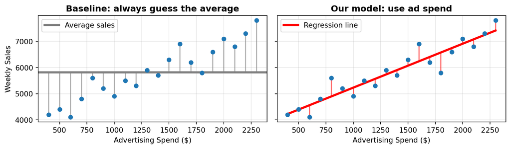

$$R^2 = 1 - \frac{\text{model's squared error}}{\text{baseline's squared error}}$$

**Our model: R² ≈ 0.89.** Using ad spend removes about **89%** of the error we’d make by guessing the average every week. In other words, it *explains 89% of the variation* in weekly sales.

## Computing Both with Scikit-Learn

You won’t compute these by hand. Scikit-learn does it in one line each:

```python
from sklearn.metrics import r2_score, root_mean_squared_error

# Predictions from the model we fit on all 20 weeks
fitted_sales = model.predict(X)

r2 = r2_score(y, fitted_sales)
rmse = root_mean_squared_error(y, fitted_sales)

print(f"R²:   {r2:.2f}")
print(f"RMSE: ${rmse:,.0f}")
```

```
R²:   0.89
RMSE: $347
```

**Note**

Both functions take the **actual values first**, then the **predictions**.

## RMSE vs. R² at a Glance

📏 RMSE

**Asks:** How far off are my predictions, typically?

**Units:** same as the target (dollars, units, minutes…)

**Better:** lower (0 = perfect)

**Our model:** “Forecasts are typically off by about **$347** per week”

📊 R²

**Asks:** How much better is my model than guessing the average?

**Units:** none (a proportion, usually 0 to 1)

**Better:** higher (1 = perfect)

**Our model:** “Ad spend explains about **89%** of the week-to-week variation in sales”

**Tip**

Use **both**: R² tells you how much of the pattern you’ve captured; RMSE tells the business what size of miss to plan for. Your readings add two more: **MAE** and **MAPE**.

## Explain It to the Manager

The store manager says: *“I can plan staffing and inventory as long as forecasts are within about **$500** a week.”*

Our model: **R² = 0.89**, **RMSE = $347**

**With your neighbor:**

1. Translate each metric into one plain-English sentence the manager would understand
2. Does our model meet the manager’s bar?
3. Which number would you lead with, and why?

## But Wait… Who Graded That?

We just scored our model on the **same 20 weeks it learned from**.

**That’s like…**

Getting the exact exam questions the night before. A perfect score proves you *memorized the answers*, not that you *learned the material*.

The manager doesn’t care how well the model “predicts” weeks that already happened.

The real question is: **how will it do on next week’s sales, which it has never seen?**

## Meet the Memorizer

Suppose we **hide 6 of our 20 weeks** and train two models on the other 14:

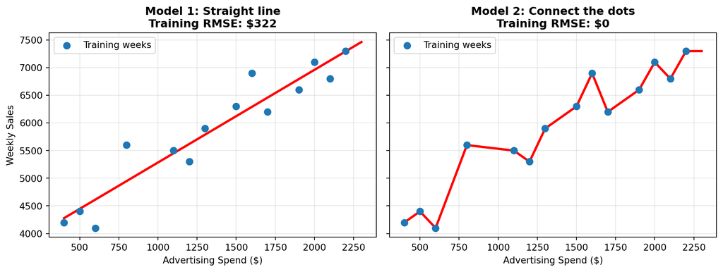

**Based on training RMSE, which model would you deploy?**

## The Reveal

Now let’s bring back the 6 hidden weeks:

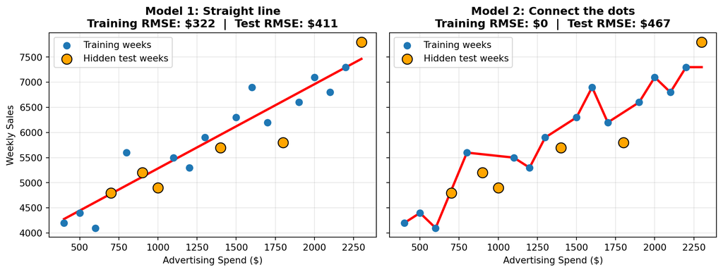

The “perfect” model is **worse** on weeks it hasn’t seen. Its $0 training score told us nothing about the future. **Only data the model never saw reveals what it actually learned.**

## The Fix: Hold Some Data Back

🗂️ Full dataset

All the historical data we have

➜

🏋️ Training set (70–80%)

The model learns the pattern here

➜

🔒 Test set (20–30%)

Locked away until the very end, then used once to score the model

➜

🔮 Test score

Our best preview of how the model will do on *future* data

**The golden rule**

The model **never sees the test set** while it’s learning. The test set stands in for the future.

## Splitting Our Data

```python
from sklearn.model_selection import train_test_split

# Hold out 30% of the weeks as a test set
X_train, X_test, y_train, y_test = train_test_split(
    X, y, test_size=0.3, random_state=11
)

print(f"Training weeks: {len(X_train)}")
print(f"Test weeks:     {len(X_test)}")
```

```
Training weeks: 14
Test weeks:     6
```

- **Four outputs**: features and target for training, features and target for testing
- **`test_size=0.3`**: hold out 30% of the rows for testing
- **`random_state=11`**: rows are assigned randomly; fixing the seed gives the same split every time you run it

## Train on Train, Score on Test

```python
# Learn ONLY from the training weeks
model = LinearRegression()
model.fit(X_train, y_train)

# Score the model on both sets
train_preds = model.predict(X_train)
test_preds = model.predict(X_test)

print(f"Training → R²: {r2_score(y_train, train_preds):.2f} | RMSE: ${root_mean_squared_error(y_train, train_preds):,.0f}")
print(f"Test     → R²: {r2_score(y_test, test_preds):.2f} | RMSE: ${root_mean_squared_error(y_test, test_preds):,.0f}")
```

```
Training → R²: 0.90 | RMSE: $322
Test     → R²: 0.83 | RMSE: $411
```

The **test** numbers are the ones we report to the manager. A test score slightly worse than the training score is normal: the model was tuned to the training weeks.

## Reading the Gap

✅ Train ≈ Test

The model **generalizes**: it learned a real pattern

Trust the test score

⚠️ Train great, Test much worse

The model **memorized** the training data (*overfitting*)

Like our connect-the-dots model

❌ Train poor, Test poor

The model is **too simple** or missing key information (*underfitting*)

Try better features or a different model

**Note**

Overfitting and underfitting get a deeper treatment in your readings, and we’ll keep coming back to them for the rest of the semester.

## Same Model, Different Split

What happens if we change only the `random_state`?

```python
for seed in [1, 3, 5, 11, 21]:
    X_tr, X_te, y_tr, y_te = train_test_split(X, y, test_size=0.3, random_state=seed)
    seed_model = LinearRegression().fit(X_tr, y_tr)
    test_rmse = root_mean_squared_error(y_te, seed_model.predict(X_te))
    print(f"random_state={seed:>2} → Test RMSE: ${test_rmse:,.0f}")
```

```
random_state= 1 → Test RMSE: $490
random_state= 3 → Test RMSE: $523
random_state= 5 → Test RMSE: $447
random_state=11 → Test RMSE: $411
random_state=21 → Test RMSE: $238
```

**Why does the test score bounce around?**

With only **6 test weeks**, the score depends heavily on *which* weeks land in the test set. More data gives more stable estimates. In Week 12, **cross-validation** solves this by testing on several different splits and averaging the results.

# Putting It All Together

## Complete Workflow: Start to Finish

Let’s see the complete machine learning workflow using a fresh dataset:

```python
# Step 1: Import a dataset
import pandas as pd
from sklearn.linear_model import LinearRegression
from sklearn.model_selection import train_test_split
from sklearn.metrics import r2_score, root_mean_squared_error

# Load the classic Advertising dataset
advertising = pd.read_csv("../data/Advertising.csv")
print("Dataset shape:", advertising.shape)
advertising.head()
```

```
Dataset shape: (200, 4)
```

|  | TV | radio | newspaper | sales |
| --- | --- | --- | --- | --- |
| 0 | 230.1 | 37.8 | 69.2 | 22.1 |
| 1 | 44.5 | 39.3 | 45.1 | 10.4 |
| 2 | 17.2 | 45.9 | 69.3 | 9.3 |
| 3 | 151.5 | 41.3 | 58.5 | 18.5 |
| 4 | 180.8 | 10.8 | 58.4 | 12.9 |

**Step 1 complete:** We have our data loaded and ready!

## Step 2: Split the Data

```python
# Step 2: Split data into features (X) and target (y), then train/test
X = advertising[['TV', 'radio', 'newspaper']]  # Multiple predictors
y = advertising['sales']  # Target variable

# Split into train/test sets
X_train, X_test, y_train, y_test = train_test_split(
    X, y, test_size=0.2, random_state=42
)

print(f"Training set: {len(X_train)} samples")
print(f"Test set: {len(X_test)} samples")
```

```
Training set: 160 samples
Test set: 40 samples
```

**Step 2 complete:** Data is properly split for honest evaluation!

## Step 3: Train the Model

```python
# Step 3: Train our regression model
model = LinearRegression()
model.fit(X_train, y_train)

# Look at our model coefficients
print("Model coefficients:")
for feature, coef in zip(X.columns, model.coef_):
    print(f"  {feature}: {coef:.3f}")
print(f"Intercept: {model.intercept_:.3f}")
```

```
Model coefficients:
  TV: 0.045
  radio: 0.189
  newspaper: 0.003
Intercept: 2.979
```

**Step 3 complete:** Model is trained and ready to make predictions!

## Step 4: Evaluate Performance

```python
# Step 4: Evaluate model performance
train_predictions = model.predict(X_train)
test_predictions = model.predict(X_test)

# Calculate metrics
train_r2 = r2_score(y_train, train_predictions)
test_r2 = r2_score(y_test, test_predictions)
train_rmse = root_mean_squared_error(y_train, train_predictions)
test_rmse = root_mean_squared_error(y_test, test_predictions)

print("Performance Summary:")
print(f"Training R²: {train_r2:.3f} | Training RMSE: {train_rmse:.2f}")
print(f"Test R²: {test_r2:.3f} | Test RMSE: {test_rmse:.2f}")
```

```
Performance Summary:
Training R²: 0.896 | Training RMSE: 1.64
Test R²: 0.899 | Test RMSE: 1.78
```

**Complete workflow achieved!** 🎉 We can now trust our model’s performance estimates.

# Looking Forward

## More in Your Readings

📖 Multiple regression

Using many predictors at once

📊 Categorical variables

Turning categories like “Region” into numbers

⚖️ Overfitting vs. underfitting

Finding the right amount of model complexity

💼 MAE & MAPE

More metrics, and how to pick the one that fits the business

## Thursday’s Lab

**This Week’s Lab Preview**

In Thursday’s lab, you’ll get hands-on practice with:

- Building regression models with real business data
- Calculating and interpreting evaluation metrics (R², RMSE, MAE)
- Using train/test splits to honestly evaluate model performance
- Connecting model results to actionable business recommendations

**Homework**

This week’s Lab will serve as your homework!

## Any Final Questions?

- About correlation vs causation?
- About regression modeling for business?
- About model evaluation metrics?
- About Thursday’s lab?

**See you Thursday for hands-on regression practice!**